# Part II - Factors determining the duration of rides

## by Akwayaga Collinus Ajinjue

## Investigation Overview

> In this investigation, I wanted to look at the factors determining the duration of rides. My main focus was on days of the week and hours of the day when the rides started, and the type of rider or user.

## Dataset Overview

> The data consisted of duration in seconds and attributes of 183,412 rides. The attributes included start_time from which I extracted the days of the week and hours of the day when the rides started. The attributes also contained user_type. 8,460 data points were removed from the analysis due to missing information.

## Distribution of Duration of rides

> Duration of rides in the dataset take on a very large range of values, from about 61 seconds as minimum to 85,444 seconds as the maximum. Plotted on a logarithmic scale, the distribution of duration of rides takes on the shape of a fairly normal distribution.
> - The distribution has a peak around 500 seconds

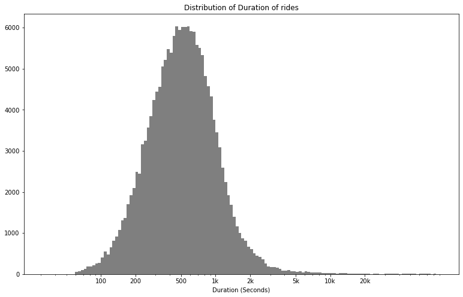

## Distribution of User Type

> `90.53%` of the riders or user type are Subscribers and `9.47%` are Customers

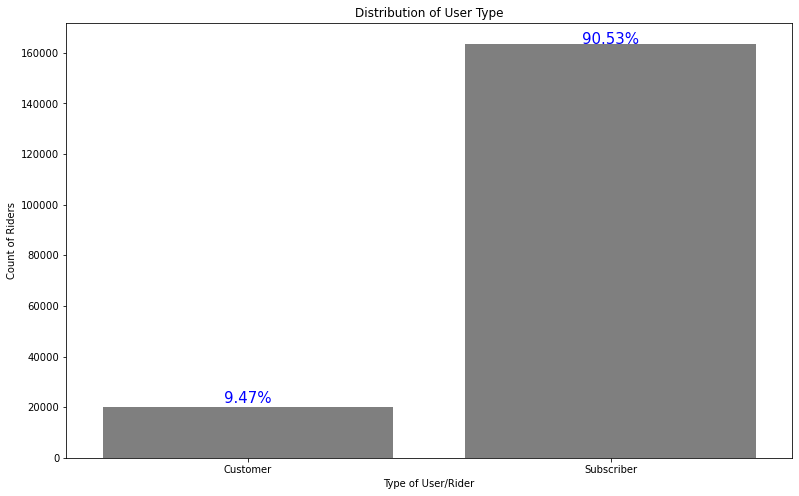

## Relationship between Duration of rides, and days of the week and hours of the day

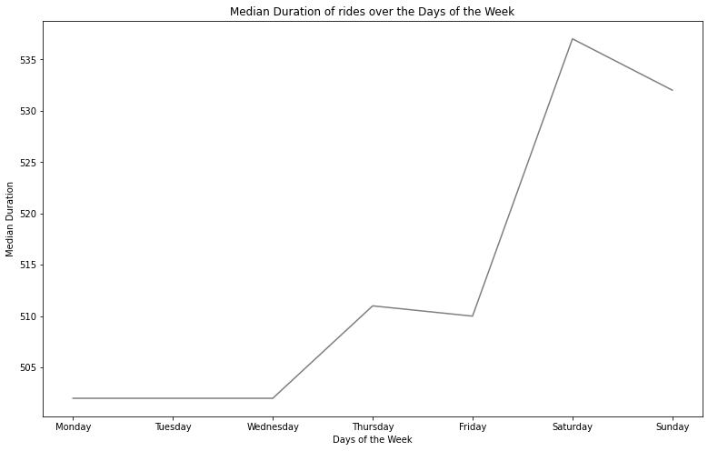

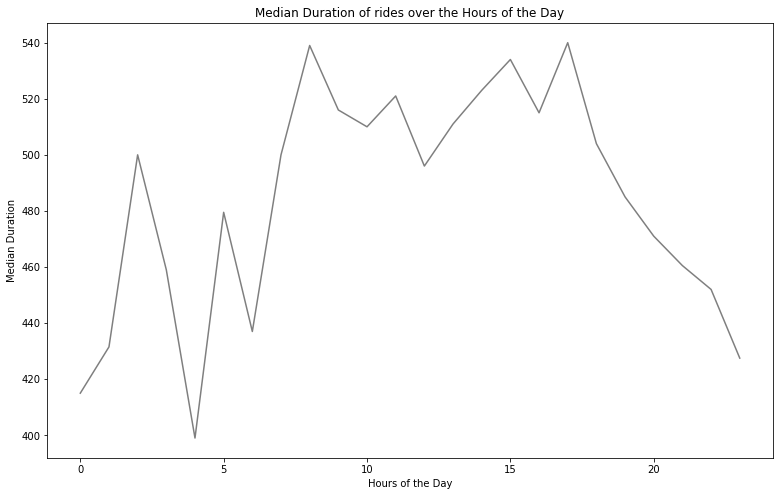

Further investigation of the median duration of rides between the 4th and 18th hours, across the days of the week and hours of the day to see if the patterns above are dependent on whether the user type is a Customer or a Subscriber.

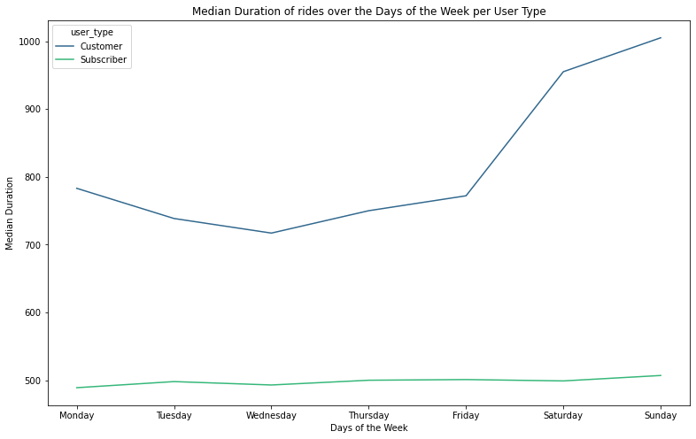

[figure not shown]